# Compare R and C implementations

```r
library(tibble)  # nice dataframes
library(ggplot2) # nice plots
library(snvecR)  # this package
```

# Introduction

The function `snvec()` uses some of the parameters of a full astronomical solution (AS) such as ZB18a from Zeebe and Lourens (2019) in combination with values for tidal dissipation (T<sub>d</sub>) and dynamical ellipticity (E<sub>d</sub>) to calculate precession and obliquity (or tilt).

In this vignette we show how we can run `snvec()` and contrast the result to pre-computed solutions, which were calculated using the [c-routine](https://github.com/rezeebe/snvec).

# Apply `snvec`

For the full 100 Myr available:

```r
dat <- snvec(-1e5, 1, 1, astronomical_solution = "full-ZB18a")
```

```
#> ℹ The astronomical solution "full-ZB18a" has not been cached.
#> ℹ Reading 'full-ZB18a.dat' from website <http://www.soest.hawaii.edu/oceanography/faculty/zeebe_files/Astro/PrecTilt/OS/ZB18a/ems-plan3.dat>.
#> ℹ Calculating helper columns.
#> ℹ The cache directory is '/tmp/RtmpGRb7Ku/snvecR2c2d2bf6a286'.
#> ℹ Saved astronomical solution with helper columns 'full-ZB18a.rds' to cache.
#> ℹ Future calls to `get_solution("full-ZB18a")` will read from the cache.
#> ! If you want to read from scratch, specify `force = TRUE`.
#> This is snvecR VERSION: 3.10.1 2025-03-05
#> Richard E. Zeebe
#> Ilja J. Kocken
#>
#> Integration parameters:
#> • `tend` = -1e+05 kyr
#> • `ed` = 1
#> • `td` = 1
#> • `astronomical_solution` = "full-ZB18a"
#> • `os_ref_frame` = "HCI"
#> • `os_omt` = defaulting to 75.594
#> • `os_inct` = defaulting to 7.155
#> • `tres` = -0.4 kyr
#> • `atol` = 1e-05
#> • `rtol` = 0
#> • `solver` = "vode"
#> ℹ started at "2025-03-05 16:06:15.983633"
#> Final values:
#> • s[1][2][3]: -0.254597659597688, -0.139890822178054, and 0.950419666189946
#> • s-error = |s|-1: -0.00617559283197311
#> Final values:
#> • obliquity: 0.399513414729974 rad
#> • precession: -2.73504927330255 rad
#> ℹ stopped at "2025-03-05 16:06:42.36054"
#> ℹ total duration: 26.38
```

# Load PT-solution

```r
pt <- get_solution("PT-ZB18a(1,1)")
```

```
#> ℹ The astronomical solution "PT-ZB18a(1.0000,1.0000)" has not been cached.
#> ℹ Reading 'PT-ZB18a(1.0000,1.0000).dat' from website <http://www.soest.hawaii.edu/oceanography/faculty/zeebe_files/Astro/PrecTilt/ZB18a/asc/PT.De1.0000Td1.0000.dat>.
#> ℹ The cache directory is '/tmp/RtmpGRb7Ku/snvecR2c2d2bf6a286'.
#> ℹ Saved astronomical solution with helper columns 'PT-ZB18a(1.0000,1.0000).rds'
#>   to cache.
#> ℹ Future calls to `get_solution("PT-ZB18a(1.0000,1.0000)")` will read from the
#>   cache.
#> ! If you want to read from scratch, specify `force = TRUE`.
```

# Inspect results

We find that despite the different ODE solvers and timesteps, the C- and R-implementations are almost identical up to -60 Myr.

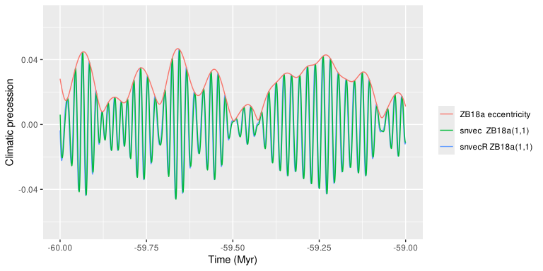

```r
pl <- ggplot(dat, aes(x = time / 1000, y = cp)) +
  labs(x = "Time (Myr)",
       y = "Climatic precession") +
  geom_line(aes(colour = "snvecR ZB18a(1,1)")) +
  geom_line(aes(colour = "snvec  ZB18a(1,1)"),
            data = pt) +
  # add eccentricity
  geom_line(aes(y = ee, colour = "ZB18a eccentricity"),
            linetype = "solid",
            data = get_solution("full-ZB18a")) +
  labs(colour = "")
pl + xlim(-60, -59)
```

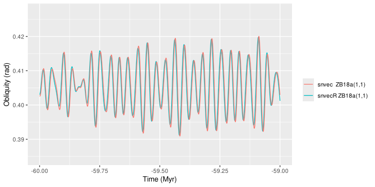

```r
plo <- ggplot(dat, aes(x = time / 1000, y = epl)) +
  labs(x = "Time (Myr)",
       y = "Obliquity (rad)") +
  geom_line(aes(colour = "snvecR ZB18a(1,1)")) +
  geom_line(aes(colour = "snvec  ZB18a(1,1)"), data = pt) +
  labs(colour = "")
plo + xlim(-60, -59)
```

But note the subtle differences at around -100 Myr. This is not significant, however, because this difference occurs far beyond the horizon of predictability in the orbital solutions (the eccentricity curves).

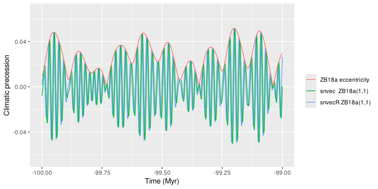

```r
pl + xlim(-100, -99)
```

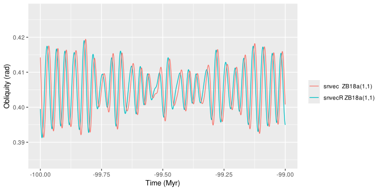

```r
plo + xlim(-100, -99)
```

# References

Zeebe, R. E., & Lourens, L. J. (2019). Solar System chaos and the Paleocene–Eocene boundary age constrained by geology and astronomy. *Science*, 365(6456), 926–929. [doi:10.1126/science.aax0612](https://doi.org/10.1126/science.aax0612).

Zeebe, R. E., & Lourens, L. J. (2022). A deep-time dating tool for paleo-applications utilizing obliquity and precession cycles: The role of dynamical ellipticity and tidal dissipation. *Paleoceanography and Paleoclimatology*, e2021PA004349. [doi:10.1029/2021PA004349](https://doi.org/10.1029/2021PA004349).